# Lab 01 — Jupyter Notebooks in VS Code

### COMM 4259 *Foundations of Machine Learning and AI*

© Jingjing Li- Ask for permission for using/quoting: jingjing.li@virginia.edu

## Lab Prep

- If you would like to see my screen on your computer, you can use a web browser to log in to Zoom, turn off the speaker and mute yourself.
  - Section 001, 11:00 a.m. – 12:15 p.m.: https://mcintire.zoom.us/j/95993311893?pwd=NmabjMgwCFyKkxzib3qMFahEDkkaSI.1
  - Section 002, 2:00 – 3:15 p.m.: https://mcintire.zoom.us/j/97629389481?pwd=GA37uPdbfC0154k4M3n17SGf6qaYCg.1
- Have VS Code open before we start. If you have not installed it yet, follow **Set Up VS Code and Python** in the Course Setup module on Canvas, or use a lab machine in Robertson Hall 317B — those are already configured.

## Lab Rules

- Raise hands for questions
- Be prepared to share your screen for Q & A or exercises

**Before this lab: open VS Code once and set it up**  
If this is your first time opening VS Code, work through **First Time Opening VS Code** (on Canvas) first. It takes about ten minutes and covers the parts that only happen once — making your `COMM 4259` and `Lab_01` folders, skipping the sign-in, opening the folder, trusting it so cells are allowed to run, and choosing the kernel.

Then run `00_setup_check.ipynb`, which came with this lab. If its three cells run, you are ready to start here.

## How This Lab Works

We write Python in **notebooks** — files ending in `.ipynb`. A notebook mixes code, the output that code produces, and written explanation in one document.

This semester we open those notebooks in **VS Code** rather than in a browser. Two things are worth separating in your head from the start:

|  | What it is |
| --- | --- |
| **Jupyter notebook** (`.ipynb`) | The *file format*. Cells of code and text, saved together with their output. |
| **VS Code** | The *editor* you open that file in. |
| **Kernel** | The Python process that actually runs your code. You pick it once per notebook. |

If you have used JupyterLab in another course, everything you learned about notebooks still applies. Only the surrounding window has changed.

## Create Your First Notebook

**Note: What is a Jupyter notebook?**  
A Jupyter notebook is a document that holds your code and that code's output in the same place, alongside text, mathematical equations, and the visualizations the code produces. That makes it a natural format for developing and presenting a data science project: the analysis and the write-up live in one file, and anyone can rerun it.

"Jupyter" is a loose acronym for Julia, Python, and R — the first languages it targeted. We will use Python throughout.

### Create a notebook

There are two ways. Either is fine.

**From the Command Palette** — the fastest, and the one worth building a habit around:

1. Press `Cmd+Shift+P` (Mac) or `Ctrl+Shift+P` (Windows). A command box opens at the top of the window.
2. Type `Create: New Jupyter Notebook` and press `Enter`.

**From the menu:**

- **File → New File… → Jupyter Notebook**

Then save it right away with `Cmd+S` / `Ctrl+S`, somewhere you can find again — a `COMM4259` folder in your Documents works well.

### Select the kernel

A new notebook is not yet attached to a Python installation. You have to say which one.

1. Look at the **top-right corner** of the notebook. It says **Select Kernel**. Click it.
2. A panel headed **Select Another Kernel** drops down. Choose **Python Environments…**

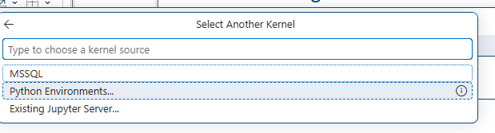

3. Pick the entry that says **base** and mentions **anaconda3** — it is labeled *Conda Env* on the right. That is the Python that has pandas, scikit-learn and matplotlib already installed.

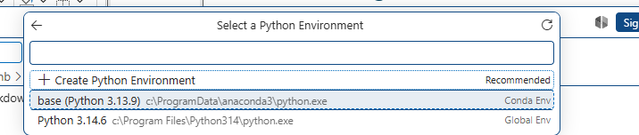

**Do not pick a bare "Python 3.x" from Program Files.**

It is a clean install with none of our packages, and every import in this lab will fail.

Once selected, the button in the top-right shows the environment name instead of "Select Kernel". VS Code remembers your choice for that notebook, so this is one click per lab.

**If "Select Kernel" shows nothing**  
The Jupyter extension did not finish installing. Reload VS Code (Command Palette → `Developer: Reload Window`) and try again. If you then get `ModuleNotFoundError: No module named pandas` when you run something, you picked the wrong interpreter — click the kernel name in the top-right and switch to **base (anaconda3)**.

### The VS Code window

Four regions matter for now.

- **Activity Bar** — the narrow strip of icons down the far left. The top one, **Explorer**, shows the files in the folder you have open. Open the `COMM 4259` folder once (**File → Open Folder…**) and every lab this semester is one click away.
- **Editor** — whatever you have open, in the middle. Your notebook appears here.
- **Notebook toolbar** — the row of buttons across the top of an open notebook: **+ Code**, **+ Markdown**, **Run All**, **Restart**, **Clear All Outputs**, and a `...` overflow menu.
- **Command Palette** — `Cmd+Shift+P` / `Ctrl+Shift+P`. Every command in VS Code is reachable by typing its name here. When you do not know where a menu item lives, this is the answer.

[figure not shown]

*First launch, before a notebook is open — so the editor is showing the Welcome page and the notebook toolbar is not visible yet. The pale blue* *Restricted Mode** bar across the top appears until you trust the folder; the first-launch handout walks through that.*

### Cells

A **cell** is a container. A notebook is a stack of them.

- A **code cell** holds Python. When you run it, the kernel executes the code and the output appears directly beneath the cell.
- A **markdown cell** holds formatted text, written in Markdown.

You can tell them apart at a glance. Hover over a code cell and a **▷ Run** button appears at its left edge; after the cell runs, the gutter shows an execution count such as `[1]`, meaning it was the first cell executed since the kernel started. Markdown cells have no Run button — they render into formatted text instead.

#### Create your first markdown cell

1. Click **+ Markdown** in the notebook toolbar. (Or press `Esc` to enter command mode, then `b` for a new cell below, then `m` to turn it into markdown.)
2. Type `This is my first markdown!`
3. Press `Ctrl+Enter` to render it.

To edit a markdown cell again after it has rendered, **double-click** it.

#### Create your first code cell

1. Click **+ Code** in the notebook toolbar. (Or press `Esc`, then `b`, then `y`.)
2. In the empty cell, type:

```
print("Hello World!")
```

3. Press `Ctrl+Enter`.
4. `Hello World!` appears below the cell, and the gutter shows an execution count.

The first time you run anything, VS Code may take a few seconds to start the kernel.

**Note: VS Code does not autosave your notebook**  
JupyterLab saves as you go. VS Code does not, by default — a **dot** on the file's tab means unsaved changes. Press `Cmd+S` / `Ctrl+S` often.

If you would rather it save itself, turn on **File → Auto Save**.

#### Save and rename your notebook

Notebooks are saved as JSON files with the extension **.ipynb** — your code, your output, and your text, all in one file.

- **Save:** `Cmd+S` / `Ctrl+S`.
- **Rename:** in the Explorer sidebar, right-click the file and choose **Rename**, or use **File → Save As…**

#### Export your notebook in another format

You will hand in some work as HTML, so that graders see your output without rerunning anything.

1. Click the `...` overflow menu in the notebook toolbar.
2. Choose **Export**, then **HTML**.
3. Pick where to save it.

The Command Palette route is `Jupyter: Export to HTML`. PDF export is offered too, but it needs extra software installed — use HTML unless an assignment says otherwise.

**Exercise: Create a "Hello World" Notebook**  
Following the instructions above, create a notebook with one cell that prints "Hello World!". Save the notebook, then export it as an HTML file.

## Interact with a Notebook

### Edit Mode vs. Command Mode

A notebook has two modes, and knowing which one you are in explains most surprises.

- **Edit mode** — you are typing *inside* a cell, and there is a blinking cursor in it. The cell's border is highlighted and the status bar at the bottom of the window shows a line and column number.

Enter edit mode by clicking into a cell's text, or by pressing `Enter` on a selected cell.

- **Command mode** — the cell is selected as a whole (a colored bar sits along its left edge) but there is no cursor inside it. Keystrokes now act on the notebook rather than going into the cell, so single letters become commands: `b` inserts a cell, `dd` deletes one.

Enter command mode by pressing `Esc`, or by clicking in the margin to the left of a cell.

**Do not try to type into a cell in command mode; unexpected things will happen.**

### Keyboard shortcuts

Running cells — these work in both modes:

1. Shift + Enter Run current cell and select below
2. Ctrl + Enter Run current cell and stay on it
3. Alt + Enter (Mac: Option + Enter) Run current cell and insert a new one below

In **command mode** (press `Esc` first):

4. a or b insert a cell above or below
5. dd delete the current cell
6. m change the cell to **Markdown**
7. y change the cell to **code**
8. x cut, c copy, v paste below
9. z undo the last cell operation
10. Shift + M merge the selected cells
11. Ctrl + Shift + - split the active cell at the cursor (in edit mode)

These come from the **Jupyter Keymap** extension, which the Jupyter extension installs for you — so the shortcuts you may know from JupyterLab still work. Any of them can be looked up or changed under **Code → Settings → Keyboard Shortcuts** (`Cmd+K Cmd+S` / `Ctrl+K Ctrl+S`).

**Notebooks in VS Code — walkthrough**  
Microsoft's written guide covers everything in this section: [Jupyter Notebooks in VS Code](https://code.visualstudio.com/docs/datascience/jupyter-notebooks). For a video, the VS Code team's [Data Science in VS Code](https://www.youtube.com/watch?v=suAkMeWJ1yE) tutorial shows the same workflow end to end.

## Code Cells

**Code cells allow you to enter and run code.** Code is run in a separate process called the **Kernel**.

### Kernels, Variables, and Environment

A notebook kernel is a "computational engine" that executes the code contained in a notebook document. There are kernels for various programming languages; we use the Python kernel, which executes Python code.

In VS Code you choose that kernel yourself the first time you run a cell in a notebook — the **Select Kernel** step above. After that, VS Code reuses your choice, and the kernel stays alive as long as the notebook is open.

```python
### This is python
print("This is a python code cell")
```

```
This is a python code cell
```

A kernel is the back-end of our notebook which not only executes our Python code, but stores our initialized variables.

```python
### For example, lets initialize variable x

x = 1738

print("x has been set to " + str(x))
```

```
x has been set to 1738
```

```python
### Print x

print(x)
```

```
1738
```

The kernel can be interrupted or restarted from the notebook toolbar: **Interrupt** stops a cell that is taking too long, and **Restart** clears the kernel's memory and starts over. (Command Palette: `Jupyter: Restart Kernel`.)

Once the kernel is restarted, everything you executed before is gone — the variables no longer exist, and the next cell you run will be **[1]** again.

Problems arise when we restart the kernel and then run code that depends on variables which have not been reinitialized. If the kernel is reset, rerun the cells where the variables are initialized. **Run All** in the toolbar does that from the top.

**Note: where `input()` asks its question**  
In JupyterLab, a prompt from `input()` appears underneath the cell. **In VS Code it appears at the top of the window**, in a box that looks like the Command Palette. Type your answer there and press `Enter`.

If a cell seems to hang with the spinner running, check the top of the window — it is probably waiting on you.

```python
## We can also run code that accepts input

name = input("What is your name? ")

print("The name you entered is " + name)
```

```
What is your name?  Jingjing Li
```

```
The name you entered is Jingjing Li
```

It is important to note that notebooks execute one cell at a time. A cell that is already running must finish before another one starts. A cell waiting its turn — or still running — shows a spinner and an execution count of `[*]` in the gutter.

```python
print("This won't print until all prior cells have finished executing.")
```

```
This won't print until all prior cells have finished executing.
```

## Markdown Cells

Markdown is a markup language that uses plain text formatting syntax. This means that we can modify the formatting of our text with the use of various symbols on our keyboard as indicators.

Some examples include:

- **Headers**
- **Text modifications such as italics and bold**
- **Ordered and Unordered lists**
- **Links**
- **Tables**
- **Images**

Now I'll showcase some examples of how this formatting is done (**double-click a markdown cell to view its source**):

### 5.1 Header

# Header 1

## Header 2

### Header 3

### 5.2 bullet points

- bullet 1
  - text
- bullet 2
  - text

### 5.3 Highlighting

1. code highlighting

```
print("H")
```

```
print(x)
```

This is how print function will work in python:

```
x = 18
print(x)
print("Hello World")
```

2. marking
3. `grey highlighting`

### 5.4 Word type

- **bold** / not bold
- *italic* or *italic*
- LaTeX equation $y = ax + b$
- Change word color some blue text

### Table

| Welcome | to |
| --- | --- |
| Class | COMM 4259 |
| Good | Luck |

### Image and link

- images

[figure not shown]

- links

[UVA Commerce School](https://www.commerce.virginia.edu/)

**Tip: preview your Markdown as you type**  
VS Code renders a markdown cell when you run it with `Ctrl+Enter`, the same as JupyterLab. While you are still editing, the syntax is colored in place, so a broken table or an unclosed `**bold**` is usually visible before you run anything.

## Exercise

**Exercise: Create a Self-Introduction Notebook**  
Create a Jupyter Notebook to introduce yourself (e.g., name, name pronunciation, concentration, hobbies, hometown and countries traveled). Specifically, it should include Markdown cells with headers, bullet points, highlighting and online images, as well as code cells that allow people to input their name and hobbies.